# TO DO: Spatially predicting ecological ordination scores

# 3 Model the ordination scores

Use a modeling/machine-learning algorithms (as long as it is not a random forest model) of your choice to model the ordination scores as a function of the obtained environmental predictors:

- Briefly explore the data, i.e., plot the response variable against each predictor and check for collinearity among the predictors.
- Dismiss strongly correlated predictors.
- Subsequently, start easy, and simply try a linear model (`lm`). Later on, you can still test further algorithms such as a GAM, support vector machines, kmeans, gradient boosting, etc.
- (Optional: Find the optimal hyperparameters (of course, using spatial cross-validation).)
- Make a prediction map based on the fitted model.

A look at Chapters [11](https://geocompr.robinlovelace.net/spatial-cv.html#spatial-cv-with-mlr) and [14](https://geocompr.robinlovelace.net/eco.html) of *Geocomputation with R* might be helpful.

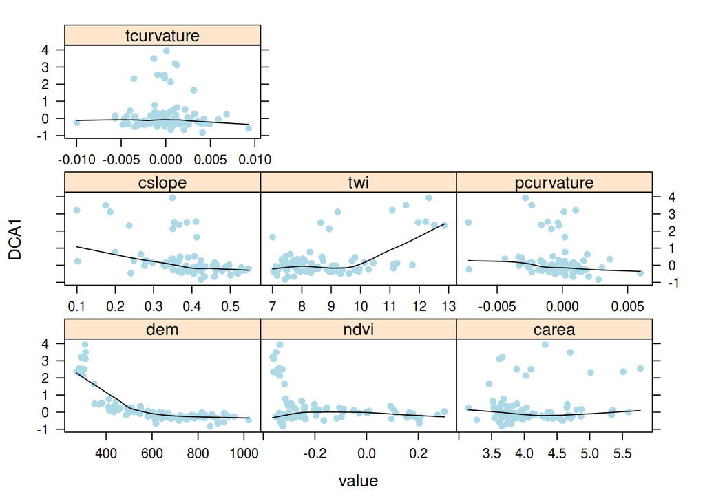

Figure 3.1: Plotting the response against possible predictors.

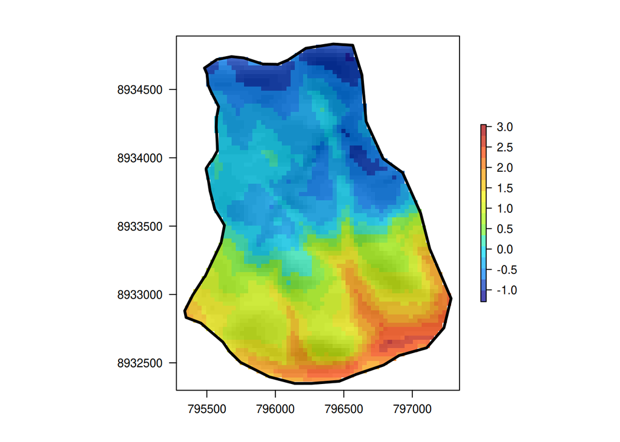

Figure 3.2: Spatial prediction of ordination scores.

# 4 Spatial cross-validation (lm)

Retrieve the bias-reduced RMSE of a linear model using spatial cross-validation (5 folds and 100 repetitions, i.e., in total 500 models have to be fitted). Report the mean RMSE and use a boxplot to visualize all retrieved RMSEs. Reading Chapter [11](https://geocompr.robinlovelace.net/spatial-cv.html#spatial-cv-with-mlr) of *Geocomputation with R* will certainly be helpful.

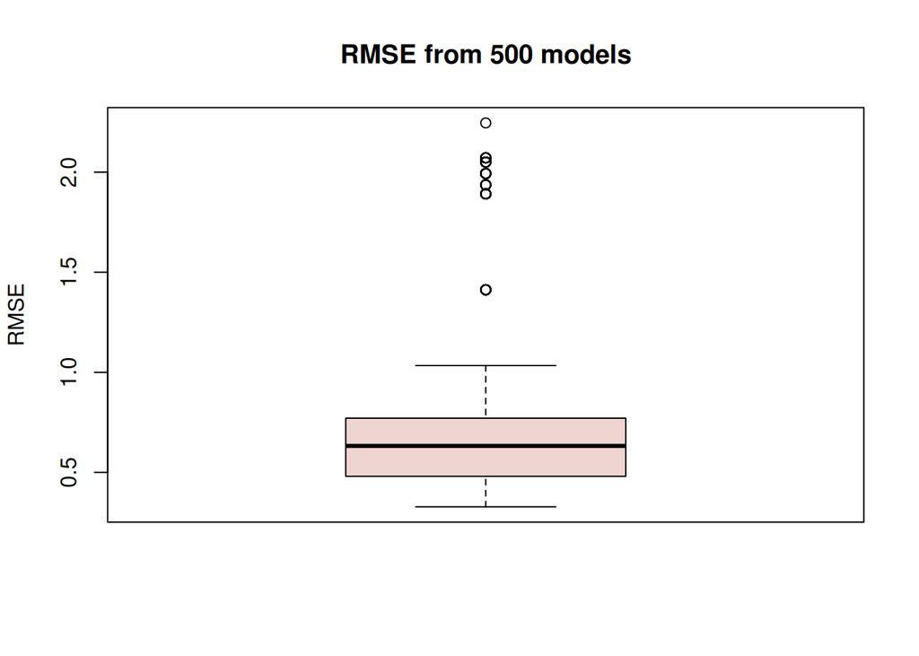

Figure 4.1: RMSE boxplot of a spatially cross-validated linear model (500 runs).

# 5 Spatial cross-validation (random forest) (optional)

Retrieve the bias-reduced RMSE of a random forest model using spatial cross-validation including the estimation of optimal hyperparameter combinations (random search with 50 iterations) in an inner tuning loop. Parallelize the tuning level. Please note that this setup implies that R has to run 125,500 models, i.e., it might take a while. Report the mean RMSE and use a boxplot to visualize all retrieved RMSEs while comparing it with the RMSE values as obtained from the linear model. Reading Chapter [14](https://geocompr.robinlovelace.net/eco.html) of *Geocomputation with R* will certainly be helpful.

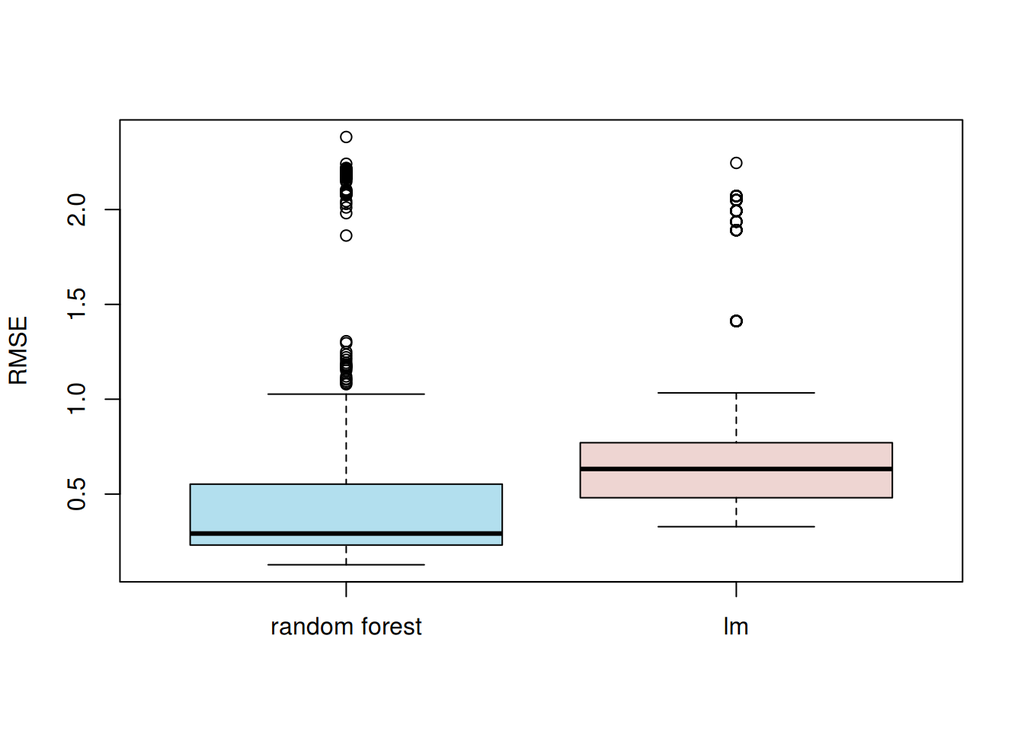

Figure 5.1: Comparing the spatial CV results of a random forest (125,500 runs) and linear model (500 runs).

Further recommended reading on spatial cross-validation:

- [Random forest paper](https://link.springer.com/article/10.1023/A:1010933404324) (Breiman 2001)
- [Spatial cross-validation paper](https://ieeexplore.ieee.org/document/6352393) (Brenning 2012)
- Statistical learning with R (James et al. 2013)
- Chapters [11](https://geocompr.robinlovelace.net/spatial-cv.html) and [14](https://geocompr.robinlovelace.net/eco.html) of *Geocomputation with R* (Lovelace, Nowosad, and Muenchow 2019)
- [Tuning random forest hyperparamters paper](https://doi.org/10.1002/widm.1301) (Probst, Wright, and Boulesteix 2019)
- [Tuning hyperparameters in a spatial modeling setting](https://doi.org/10.1016/j.ecolmodel.2019.06.002) (Schratz et al. 2019)

# References

Borcard, Daniel, François Gillet, and Pierre Legendre. 2018. *Numerical Ecology with R*. Use R! http://public.ebookcentral.proquest.com/choice/publicfullrecord.aspx?p=5347221.

Breiman, Leo. 2001. “Random Forests.” *Machine Learning* 45 (1): 5–32. https://doi.org/10.1023/A:1010933404324.

Brenning, Alexander. 2012. “Spatial Cross-Validation and Bootstrap for the Assessment of Prediction Rules in Remote Sensing: The R Package Sperrorest.” In, 5372–5. IEEE. https://doi.org/10.1109/IGARSS.2012.6352393.

James, Gareth, Daniela Witten, Trevor Hastie, and Robert Tibshirani. 2013. *An Introduction to Statistical Learning: With Applications in R*. Springer Science & Business Media.

Lovelace, Robin, Jakub Nowosad, and Jannes Muenchow. 2019. *Geocomputation with R*. The R Series. CRC Press.

Muenchow, Jannes, Achim Bräuning, Eric Frank Rodríguez, and Henrik von Wehrden. 2013. “Predictive Mapping of Species Richness and Plant Species’ Distributions of a Peruvian Fog Oasis Along an Altitudinal Gradient.” *Biotropica* 45 (5): 557–66. https://doi.org/10.1111/btp.12049.

Muenchow, Jannes, Patrick Schratz, and Alexander Brenning. 2017. “RQGIS: Integrating R with QGIS for Statistical Geocomputing.” *The R Journal* 9 (2): 409–28. https://doi.org/10.32614/RJ-2017-067.

Pielou, E. C. 1984. *The Interpretation of Ecological Data: A Primer on Classification and Ordination*. John Wiley & Sons.

Probst, Philipp, Marvin N. Wright, and Anne-Laure Boulesteix. 2019. “Hyperparameters and Tuning Strategies for Random Forest.” *Wiley Interdisciplinary Reviews: Data Mining and Knowledge Discovery* 9 (3): e1301. https://doi.org/10.1002/widm.1301.

Schratz, Patrick, Jannes Muenchow, Eugenia Iturritxa, Jakob Richter, and Alexander Brenning. 2019. “Hyperparameter Tuning and Performance Assessment of Statistical and Machine-Learning Algorithms Using Spatial Data.” *Ecological Modelling* 406: 109–20. https://doi.org/10.1016/j.ecolmodel.2019.06.002.

Zuur, Alain F., Elena N. Ieno, and Graham M. Smith. 2007. *Analysing Ecological Data*. Statistics for Biology and Health. New York, NY: Springer.